# Task 12

Take me out to the ball game

Kyle Tolliver

March 16, 2020

```r
# Use this R-Chunk to import all your datasets!
dat <- blscrapeR::inflation_adjust(2017) %>%
  mutate(yearID = as.numeric(year)) %>%
  select(-year)
playerdat <- People %>%
  unite(name, nameLast, nameFirst, sep = "_") %>%
  select(playerID, name)
salarydat <- Salaries %>%
  mutate(base_year = "2017") %>%
  select(yearID, playerID, salary, base_year)
collegedat <- Schools %>%
  select(-country)
playingdat <- CollegePlaying %>%
  select(-yearID)
```

```r
View(dat)
View(playerdat)
View(salarydat)
View(collegedat)
View(playingdat)
```

## Reading

- Chapter 13: R for Data Science - Relational Data

## Tasks

[X] Take notes on your reading of the specified ‘R for Data Science’ chapter in the README.md or in a ‘.R’ script in the class task folder

[X] Install the library(Lahman) and examine the available data sets available

- Find the 4-5 different data sets that you will need to show full college and player names as well as their annual earnings

[X] Install the library(blscrapeR) and use the inflation_adjust(2017) function to get all earnings in 2017 dollars

[X] Make a plot showing how professional baseball player earnings that played baseball at BYU compared to the players from other Utah schools

[X] Save your .R script and image to your repository and be ready to share your code and image at the beginning of class

## Data Wrangling

### Joining

```r
playersal <- left_join(playerdat, salarydat) %>%
  select(-base_year)
collegeplaying <- left_join(collegedat, playingdat)
college <- left_join(playersal, collegeplaying, by = "playerID")
masterdat <- left_join(college, dat, by = "yearID") %>%
  na.omit() %>%
  filter(state == "UT") %>%
  filter(!schoolID %in% c("eutah", "utslxxo", "sutah")) %>%
  mutate(increase = as.numeric(pct_increase/100)) %>%
  mutate(salary2017 = (-1 * (salary / increase)) + 1)
baseball <- masterdat %>%
  select(playerID, name, yearID, name_full, schoolID, salary2017) %>%
  group_by(playerID, name, name_full, schoolID) %>%
  summarize(career_earnings = sum(salary2017)) %>%
  distinct()
```

```r
View(playersal)
View(collegeplaying)
View(college)
View(masterdat)
View(baseball)
```

## Data Visualization

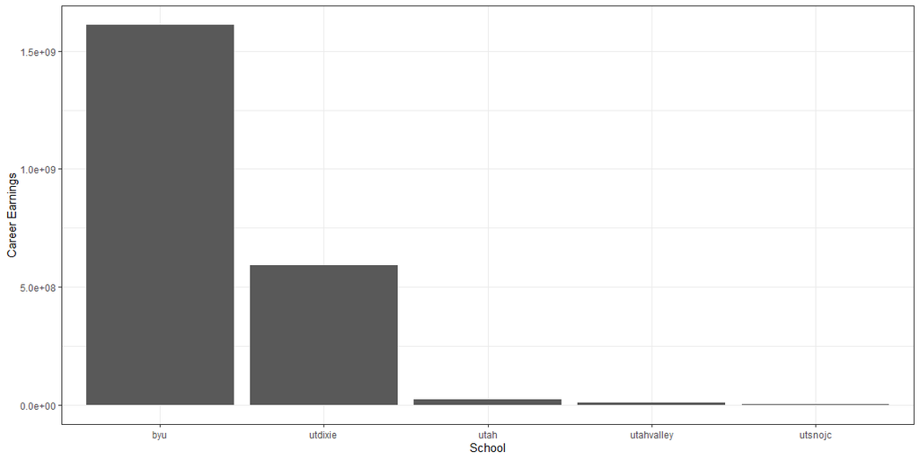

```r
ggplot(data = baseball, aes(x = fct_reorder(schoolID, career_earnings, .fun = max, .desc = TRUE), y = career_earnings)) +
  geom_col() +
  labs(x = "School", y = "Career Earnings") +
  theme_bw()
```

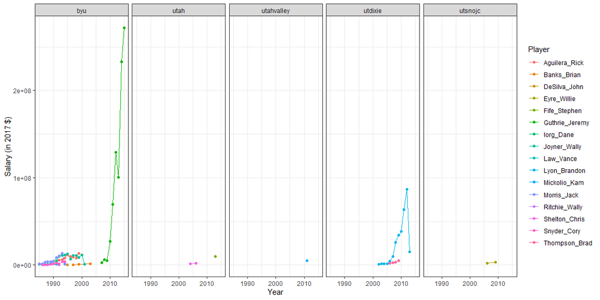

```r
ggplot(data = masterdat, aes(x = yearID, y = salary2017, color = name)) +
  facet_wrap(~schoolID, nrow = 1) +
  geom_line() + geom_point() +
  labs(x = "Year", y = "Salary (in 2017 $)", color = "Player") +
  theme_bw()
```

## Reading Notes

### Ch 13

- Mutating joins, which add new variables to one data frame from matching observations in another
- Filtering joins, which filter observations from one data frame based on whether or not they match an observation in the other table
- Set operations, which treat observations as if they were set elements
- A primary key uniquely identifies an observation in its own table
- A foreign key uniquely identifies an observation in another table
- The simplest type of join is the inner join. An inner join matches pairs of observations whenever their keys are equal: (To be precise, this is an inner equijoin because the keys are matched using the equality operator. Since most joins are equijoins we usually drop that specification.)
- An outer join keeps observations that appear in at least one of the tables
- A left join keeps all observations in x
- A right join keeps all observations in y
- A full join keeps all observations in x and y
- A natural join uses all variables that appear in both tables
- semi_join(x, y) keeps all observations in x that have a match in y
- anti_join(x, y) drops all observations in x that have a match in y
- intersect(x, y): return only observations in both x and y
- union(x, y): return unique observations in x and y
- setdiff(x, y): return observations in x, but not in y